# Plots/ggplot2 (solutions)

## Primary exercises

1. *Necessary libraries and data*.  
   In your R Markdown document load the `tidyverse` library and read the `pulse.csv` file into the `pulse` variable.
2. *A series of charts*.  
   Reproduce the sequence of charts.  
   Each next chart is a small modification of the command.

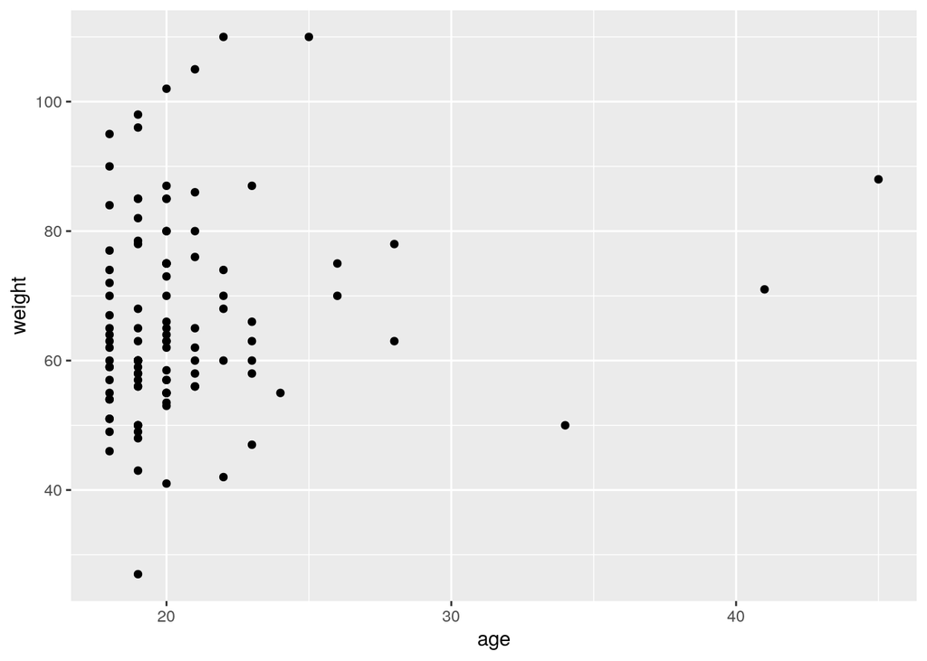

```r
ggplot( pulse, aes( x = age, y = weight ) ) +
  geom_point()
```

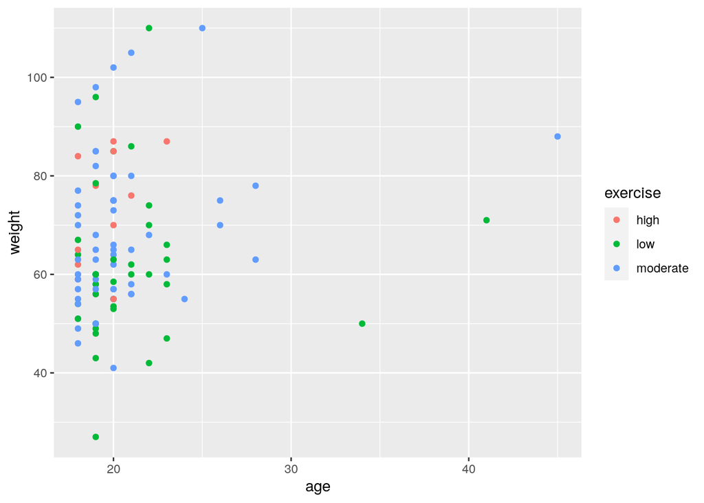

```r
ggplot( pulse, aes( x = age, y = weight ) ) +
  geom_point( aes( color = exercise ) )
```

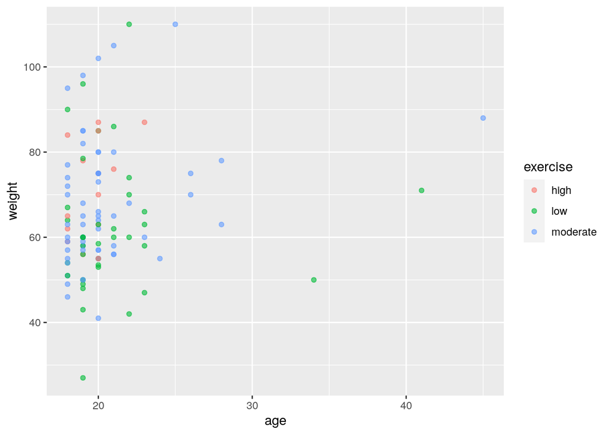

```r
ggplot( pulse, aes( x = age, y = weight ) ) +
  geom_point( aes( color = exercise ), alpha = 0.6 )
```

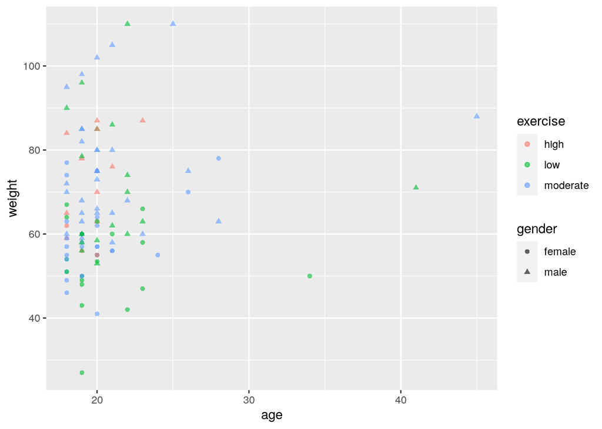

```r
ggplot( pulse, aes( x = age, y = weight ) ) +
  geom_point( aes( color = exercise, shape = gender ), alpha = 0.6 )
```

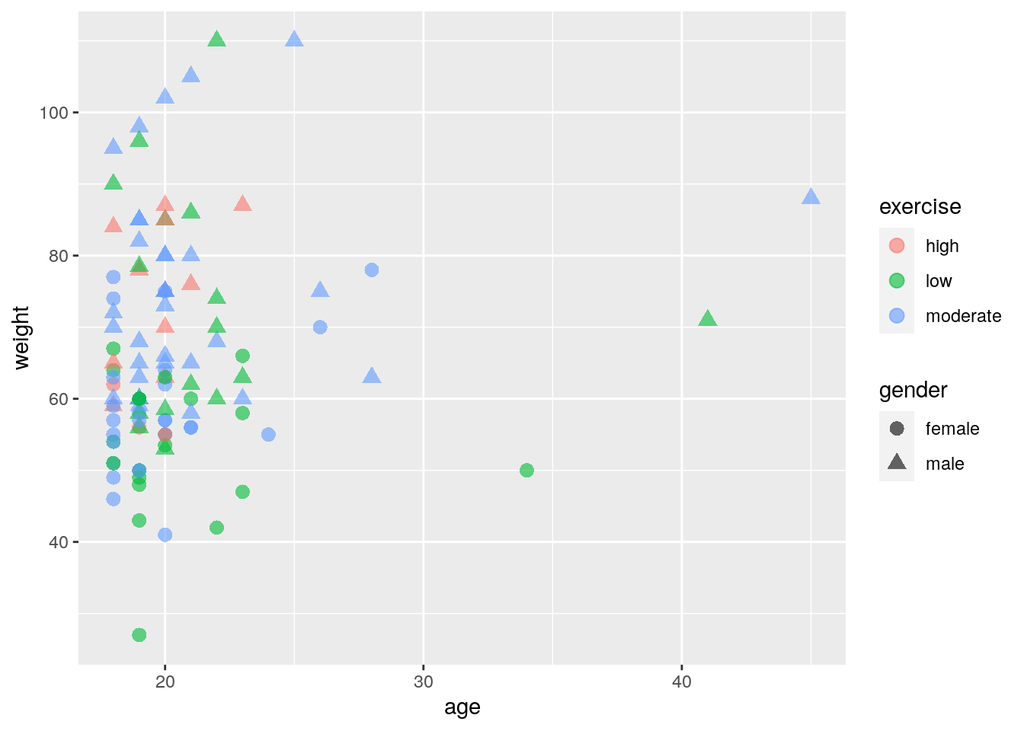

```r
ggplot( pulse, aes( x = age, y = weight ) ) +
  geom_point( aes( color = exercise, shape = gender ), alpha = 0.6, size = 3 )
```

3. *Labels*.  
   Check `Help` for commands `xlab`, `ylab`, `ggtitle`.  
   Adjust the last chart to get the chart below.

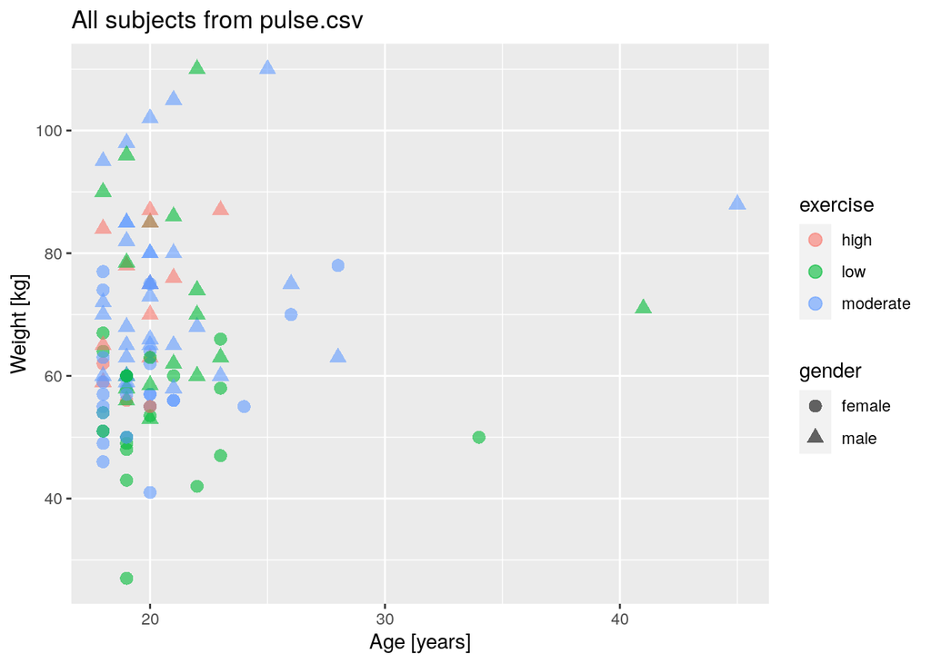

```r
ggplot( pulse, aes( x = age, y = weight ) ) +
  geom_point( aes( color = exercise, shape = gender ), alpha = 0.6, size = 3 ) +
  xlab( "Age [years]" ) + ylab( "Weight [kg]" ) +
  ggtitle( "All subjects from pulse.csv" )
```

## Extra exercises

1. *Multiple layers*.  
   There can be more than one `geom_` component in a single plot.  
   Compose two `geom_point` components (so, add one more than used above) to reproduce the following chart.

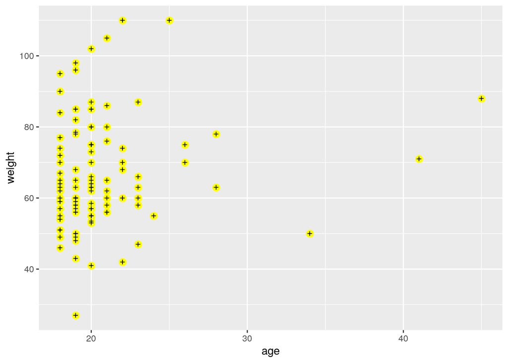

```r
ggplot( pulse, aes( x = age, y = weight ) ) +
  geom_point( color = "yellow", size = 3 ) +
  geom_point( color = "black", size = 1, shape = 3 )
```

2. *Different data in layers*.  
   By default, `geom_` functions use the data provided in the call to the `ggplot` function.  
   This can be changed with the `data` argument: `geom_point( data = otherData )`.  
   Use the function `filter` to select from `pulse` all subjects with `height >= 190`; store the result in `filtPulse`. Now, modify the previous plot to draw the black symbol only for `filtPulse` subjects.

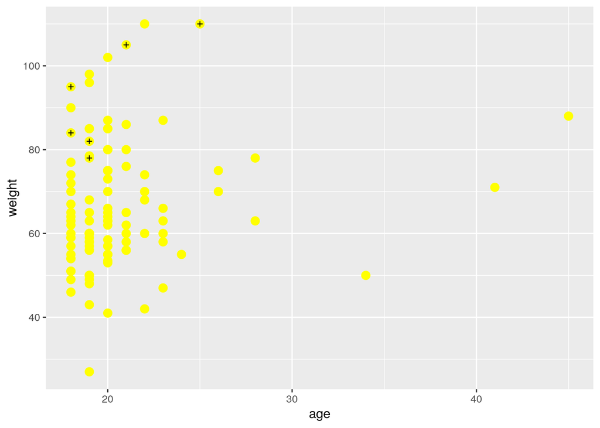

```r
filtPulse <- pulse %>% filter( height >= 190 )
ggplot( pulse, aes( x = age, y = weight ) ) +
  geom_point( color = "yellow", size = 3 ) +
  geom_point( color = "black", size = 1, shape = 3, data = filtPulse )
```